# Penanganan Autokorelasi dengan Cochrane-Orcutt dan Hildreth-Lu

### Metode Hildreth-Lu

Penanganan kedua adalah menggunakan metode Hildreth-Lu. Metode ini akan mencari nilai SSE terkecil dan dapat dicari secara manual maupun menggunakan packages. Jika menggunakan packages, gunakan `library` *packages* `HORM`.

```r
#Penanganan Autokorelasi Hildreth lu
# Hildreth-Lu
hildreth.lu.func<- function(r, model){
  x1 <- model.matrix(model)[,2]
  x2 <- model.matrix(model)[,3]
  x3 <- model.matrix(model)[,4]

  y <- model.response(model.frame(model))
  n <- length(y)
  t <- 2:n
  y <- y[t]-r*y[t-1]
  x1 <- x1[t]-r*x1[t-1]
  x2 <- x2[t]-r*x2[t-1]
  x3 <- x3[t]-r*x3[t-1]


  return(lm(y~x1+x2+x3))
}

#Pencariab rho yang meminimumkan SSE
r <- c(seq(0.1,0.9, by= 0.1))
tab <- data.frame("rho" = r, "SSE" = sapply(r, function(i){deviance(hildreth.lu.func(i, model_aqi))}))
round(tab, 4)
```

```
##   rho     SSE
## 1 0.1 12.0739
## 2 0.2 10.0700
## 3 0.3  8.7231
## 4 0.4  8.0226
## 5 0.5  7.9523
## 6 0.6  8.4915
## 7 0.7  9.6241
## 8 0.8 11.3621
## 9 0.9 13.7733
```

```r
#Rho optimal di sekitar 0.4
rOpt <- seq(0.4,0.5, by= 0.001)
tabOpt <- data.frame("rho" = rOpt, "SSE" = sapply(rOpt, function(i){deviance(hildreth.lu.func(i, model_aqi))}))
head(tabOpt[order(tabOpt$SSE),])
```

```
##      rho      SSE
## 62 0.461 7.905986
## 63 0.462 7.906004
## 61 0.460 7.906030
## 64 0.463 7.906084
## 60 0.459 7.906136
## 65 0.464 7.906225
```

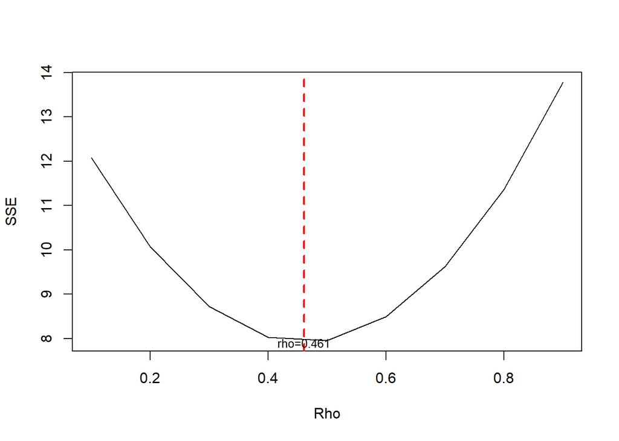

```r
#Grafik SSE optimum
par(mfrow = c(1,1))
plot(tab$SSE ~ tab$rho , type = "l", xlab = "Rho", ylab = "SSE")
abline(v = tabOpt[tabOpt$SSE==min(tabOpt$SSE),"rho"], lty = 2, col="red",lwd=2)
text(x=0.461, y=7.905986, labels = "rho=0.461", cex = 0.8)
```

Perhitungan yang dilakukan aplikasi `R` menunjukkan bahwa nilai $ρ$ optimum, yaitu saat SSE terkecil terdapat pada nilai $ρ=0.461$. Hal tersebut juga ditunjukkan pada plot. Selanjutnya, model dapat didapatkan dengan mengevaluasi nilai $ρ$ ke dalam fungsi `hildreth.lu.func`, serta dilanjutkan dengan pengujian autokorelasi dengan uji Durbin-Watson. Namun, setelah pengecekan tersebut tidak lupa koefisien regresi tersebut digunakan untuk transformasi balik. Persamaan hasil transformasi itulah yang menjadi persamaan sesungguhnya.

```r
#Model terbaik
modelHL <- hildreth.lu.func(0.461, model_aqi)
summary(modelHL)
```

```
##
## Call:
## lm(formula = y ~ x1 + x2 + x3)
##
## Residuals:
##      Min       1Q   Median       3Q      Max
## -0.93664 -0.23231  0.04208  0.18384  0.79297
##
## Coefficients:
##             Estimate Std. Error t value Pr(>|t|)
## (Intercept)  2.68575    3.13731   0.856    0.395
## x1          -0.03142    0.02819  -1.115    0.269
## x2           0.48393    0.01940  24.948   <2e-16 ***
## x3          -0.02506    2.69806  -0.009    0.993
## ---
## Signif. codes:  0 '***' 0.001 '**' 0.01 '*' 0.05 '.' 0.1 ' ' 1
##
## Residual standard error: 0.3435 on 67 degrees of freedom
## Multiple R-squared:  0.9635, Adjusted R-squared:  0.9619
## F-statistic:   590 on 3 and 67 DF,  p-value: < 2.2e-16
```

```r
#Transformasi Balik
cat("y = ", coef(modelHL)[1]/(1-0.461), "+", coef(modelHL)[2],"x", sep = "")
```

```
## y = 4.98283+-0.03142007x
```

```r
#Deteksi autokorelasi
dwtest(modelHL)
```

```
##
##  Durbin-Watson test
##
## data:  modelHL
## DW = 2.7168, p-value = 0.9976
## alternative hypothesis: true autocorrelation is greater than 0
```

Terakhir, akan dibandingkan nilai SSE dari ketiga metode (metode awal, metode Cochrane-Orcutt, dan Hildreth-Lu).

```r
#Perbandingan
sseModelawal <- anova(model_aqi)$`Sum Sq`[-c(1,2,3)]
sseModelCO <- anova(modelCOmanual)$`Sum Sq`[-c(1,2,3)]
sseModelHL <- anova(modelHL)$`Sum Sq`[-c(1,2,3)]
mseModelawal <- sseModelawal/length(df$AQI)
mseModelCO <- sseModelCO/length(df$AQI)
mseModelHL <- sseModelHL/length(df$AQI)
akurasi <- matrix(c(sseModelawal,sseModelCO,sseModelHL,
                    mseModelawal,mseModelCO,mseModelHL),nrow=2,ncol=3,byrow = T)
colnames(akurasi) <- c("Model_Awal", "Model_Cochrane-Orcutt", "Model_Hildreth-Lu")
row.names(akurasi) <- c("SSE","MSE")
akurasi
```

```
##     Model_Awal Model_Cochrane-Orcutt Model_Hildreth-Lu
## SSE 33.6474846             7.9059848         7.9059861
## MSE  0.4673262             0.1098053         0.1098054
```

Hasil penanganan autokorelasi dengan metode Cochrane-Orcutt dan Hildreth-Lu memiliki nilai `SSE` sebesar $7.9059861$. Jauh lebih rendah dibandingkan model awal dengan SSE sebesar $33.6474846 $. Hal ini menunjukkan bahwa model setelah penanganan lebih baik dibandingkan model awal ketika autokorelasi masih terjadi.

Kesimpulan: Pada data yang digunakan, metode Cochrane-Orcutt dan Hildreth-Lu terbukti efektif dalam menangani autokorelasi.